# Google Data Analytics Capstone Project-Bellabeat

## Background

Bellabeat is a high-tech company that manufactures health-focused smart products for woman. With an aim to empower women with knowledge about their own health and habits by easily tracking their overall health and wellness, Bellabeat has been working as a tech-driven wellness company for women since 2013.

## PHASE 1: ASK

### Business Task

Bellabeat's co-founder and Chief Creative Officer, Urska Srsen, believes that an analysis of Bellabeat's available consumer data would reveal more opportunities for growth. So, she asked the marketing analytics team to focus on a Bellabeat product and analyze smart device usage data in order to gain insight into how people are already using their smart devices. Then,using this information, she would like:  
• High-level recommendations for how these trends can inform Bellabeat marketing strategy.  
• Analyze this smart device usage data to gain insight into how consumers use non-Bellabeat smart devices.

### Products

**Bellabeat app:** The Bellabeat app provides users with health data related to their activity, sleep, stress, menstrual cycle, and mindfulness habits. This data can help users better understand their current habits and make healthy decisions. The Bellabeat app connects to their line of smart wellness products.  
**Leaf:** Bellabeat’s classic wellness tracker can be worn as a bracelet, necklace, or clip. The Leaf tracker connects to the Bellabeat app to track activity, sleep, and stress.  
**Time:** This wellness watch combines the timeless look of a classic timepiece with smart technology to track user activity, sleep, and stress. The Time watch connects to the Bellabeat app to provide you with insights into your daily wellness.  
**Spring:** This is a water bottle that tracks daily water intake using smart technology to ensure that you are appropriately hydrated throughout the day. The Spring bottle connects to the Bellabeat app to track your hydration levels.  
**Bellabeat membership:** Bellabeat also offers a subscription-based membership program for users. Membership gives users 24/7 access to fully personalized guidance on nutrition, activity, sleep, health and beauty, and mindfulness based on their lifestyle and goals.

### Guiding Questions

1. What are some trends in smart device usage?
2. How to apply these trends to Bellabeat customers?
3. How can these trends help influence Bellabeat marketing strategy?

### Stakeholders

**The Primary Stakeholder:**  
• Urska Srsen - Chief Executive Officer (CEO) and co-founder of Bellabeat  
• Sando Mur - Mathematician and co-founder of Bellabeat  
**Secondary Stakeholder:**  
• Bellabeat Marketing Analytics Team

## Phase 2: Prepare

### Bias or Credibility of the Data

**Originality:** The data was originally collected from Amazon Mechanical Murk, hence not an original dataset.

**Comprehensiveness:** No information regarding participants age, gender, name was present in the dataset which makes the data non comprehensive. This could mean that data was not randomized. If the data is biased, then the insights from the analysis will be unfair to all types of people.

**Current:** The data is currently outdated as it was collected in 2016 which is too early to state the current trends.

**Cited:** The dataset has been created by Amazon Mechanical Murk, but the citation of the data has no information to state whether it is credible.

## Phase 3: Process

### Tool Used

For the processing step, I will be using R as the preferred analytics tool. I will be using various R packages for processing and analyzing the data.

### Importing R packages

For the processing step, I will be using R as the preferred analytics tool. I will be using various R packages for processing and analyzing the data.

```r
install.packages("ggplot2")
```

[output not shown]

[output not shown]

```r
install.packages("tidyverse")
```

[output not shown]

[output not shown]

```r
install.packages("dplyr")
```

[output not shown]

[output not shown]

```r
install.packages("readr")
```

[output not shown]

[output not shown]

```r
install.packages("magrittr")
```

```r
install.packages("ggpubr")
```

[output not shown]

[output not shown]

```r
install.packages("lubridate")
```

[output not shown]

```r
install.packages("janitor")
```

[output not shown]

[output not shown]

```r
library(ggplot2)
```

```r
library(tidyverse)
```

```r
library(dplyr)
```

```r
library(readr)
```

```r
library(magrittr)
```

[output not shown]

```r
library(ggpubr)
```

[output not shown]

```r
library(lubridate)
```

```r
library(janitor)
```

[output not shown]

```r
daily_activity <- read.csv("C:\\Users\\HP\\.ipynb_checkpoints\\dailyActivity_merged.csv")
```

```r
sleep_day <- read.csv("C:\\Users\\HP\\.ipynb_checkpoints\\sleepDay_merged.csv")
```

### Cleaning Dataset

```r
head(daily_activity)
```

| Id | ActivityDate | TotalSteps | TotalDistance | TrackerDistance | LoggedActivitiesDistance | VeryActiveDistance | ModeratelyActiveDistance | LightActiveDistance | SedentaryActiveDistance | VeryActiveMinutes | FairlyActiveMinutes | LightlyActiveMinutes | SedentaryMinutes | Calories |
| --- | --- | --- | --- | --- | --- | --- | --- | --- | --- | --- | --- | --- | --- | --- |
| 1503960366 | 4/12/2016 | 13162 | 8.50 | 8.50 | 0 | 1.88 | 0.55 | 6.06 | 0 | 25 | 13 | 328 | 728 | 1985 |
| 1503960366 | 4/13/2016 | 10735 | 6.97 | 6.97 | 0 | 1.57 | 0.69 | 4.71 | 0 | 21 | 19 | 217 | 776 | 1797 |
| 1503960366 | 4/14/2016 | 10460 | 6.74 | 6.74 | 0 | 2.44 | 0.40 | 3.91 | 0 | 30 | 11 | 181 | 1218 | 1776 |
| 1503960366 | 4/15/2016 | 9762 | 6.28 | 6.28 | 0 | 2.14 | 1.26 | 2.83 | 0 | 29 | 34 | 209 | 726 | 1745 |
| 1503960366 | 4/16/2016 | 12669 | 8.16 | 8.16 | 0 | 2.71 | 0.41 | 5.04 | 0 | 36 | 10 | 221 | 773 | 1863 |
| 1503960366 | 4/17/2016 | 9705 | 6.48 | 6.48 | 0 | 3.19 | 0.78 | 2.51 | 0 | 38 | 20 | 164 | 539 | 1728 |

```r
head(sleep_day)
```

| Id | SleepDay | TotalSleepRecords | TotalMinutesAsleep | TotalTimeInBed |
| --- | --- | --- | --- | --- |
| 1503960366 | 4/12/2016 12:00:00 AM | 1 | 327 | 346 |
| 1503960366 | 4/13/2016 12:00:00 AM | 2 | 384 | 407 |
| 1503960366 | 4/15/2016 12:00:00 AM | 1 | 412 | 442 |
| 1503960366 | 4/16/2016 12:00:00 AM | 2 | 340 | 367 |
| 1503960366 | 4/17/2016 12:00:00 AM | 1 | 700 | 712 |
| 1503960366 | 4/19/2016 12:00:00 AM | 1 | 304 | 320 |

Separate Date and Time in Sleepday column of the sleep_day file using separate() function.

```r
sleep_day_new <- sleep_day %>%
  separate(SleepDay, c("Date", "Time"), " ")
```

Identifying column names

```r
colnames(daily_activity)
```

1. 'Id'

2. 'ActivityDate'

3. 'TotalSteps'

4. 'TotalDistance'

5. 'TrackerDistance'

6. 'LoggedActivitiesDistance'

7. 'VeryActiveDistance'

8. 'ModeratelyActiveDistance'

9. 'LightActiveDistance'

10. 'SedentaryActiveDistance'

11. 'VeryActiveMinutes'

12. 'FairlyActiveMinutes'

13. 'LightlyActiveMinutes'

14. 'SedentaryMinutes'

15. 'Calories'

```r
colnames(sleep_day_new)
```

1. 'Id'

2. 'Date'

3. 'Time'

4. 'TotalSleepRecords'

5. 'TotalMinutesAsleep'

6. 'TotalTimeInBed'

Find distinct users in each dataframe

```r
n_distinct(daily_activity$Id)
```

33

```r
n_distinct(sleep_day_new$Id)
```

24

Identifying total number of rows

```r
nrow(daily_activity)
```

940

```r
nrow(sleep_day_new)
```

413

Checking for duplicate values

```r
nrow(daily_activity[duplicated(daily_activity),])
```

0

```r
nrow(sleep_day_new[duplicated(sleep_day_new),])
```

3

Removing duplicates from sleep_day

```r
sleep_day_new <- unique(sleep_day_new)
nrow(sleep_day_new)
```

410

Removing "0" values

```r
daily_activity <- daily_activity %>% filter(TotalSteps !=0)
daily_activity <- daily_activity %>%  filter(TotalDistance !=0)
```

## Phase 4: Analyze

### Summarizing daily_activity dataframe

```r
daily_activity %>%
  select(TotalSteps,
         TotalDistance,
         VeryActiveMinutes,
         FairlyActiveMinutes,
         LightlyActiveMinutes,
         SedentaryMinutes,
         Calories) %>%
  summary()
```

```
   TotalSteps    TotalDistance    VeryActiveMinutes FairlyActiveMinutes
 Min.   :    8   Min.   : 0.010   Min.   :  0.00    Min.   :  0.00
 1st Qu.: 4927   1st Qu.: 3.373   1st Qu.:  0.00    1st Qu.:  0.00
 Median : 8054   Median : 5.590   Median :  7.00    Median :  8.00
 Mean   : 8329   Mean   : 5.986   Mean   : 23.04    Mean   : 14.79
 3rd Qu.:11096   3rd Qu.: 7.905   3rd Qu.: 35.00    3rd Qu.: 21.00
 Max.   :36019   Max.   :28.030   Max.   :210.00    Max.   :143.00
 LightlyActiveMinutes SedentaryMinutes    Calories
 Min.   :  0.0        Min.   :   0.0   Min.   :  52
 1st Qu.:147.0        1st Qu.: 721.2   1st Qu.:1857
 Median :208.5        Median :1020.5   Median :2220
 Mean   :210.3        Mean   : 955.2   Mean   :2362
 3rd Qu.:272.0        3rd Qu.:1189.0   3rd Qu.:2832
 Max.   :518.0        Max.   :1440.0   Max.   :4900
```

**Observations:**

- Average very active minutes were at 23.04 minutes
- Average fairly active minutes were at 14.79 minutes.
- Average lightly active minutes were at 210.3 minutes.
- Average sedentary minutes were at 955.2 minutes.
- The average amount of calories burnt per day was around 2362kcal.

**Assumptions:**

- Participants were highly inactive throughout the day.
- Participants spent a low amount of time exercising.
- Participants were highly unlikely to take part in any kind of strong activities.

### Summarizing sleep_day_new dataframe

```r
sleep_day_new %>%
  select(TotalSleepRecords,
         TotalMinutesAsleep,
         TotalTimeInBed) %>%
  summary()
```

```
 TotalSleepRecords TotalMinutesAsleep TotalTimeInBed
 Min.   :1.00      Min.   : 58.0      Min.   : 61.0
 1st Qu.:1.00      1st Qu.:361.0      1st Qu.:403.8
 Median :1.00      Median :432.5      Median :463.0
 Mean   :1.12      Mean   :419.2      Mean   :458.5
 3rd Qu.:1.00      3rd Qu.:490.0      3rd Qu.:526.0
 Max.   :3.00      Max.   :796.0      Max.   :961.0
```

**Assumptions:**

Participants had an adequate amount of sleep.

## Phase 5: Share

In this step, we will view different type of visualisations to find relationships between the variables.

**Relationship between the Total number of Steps and Calories burned:**

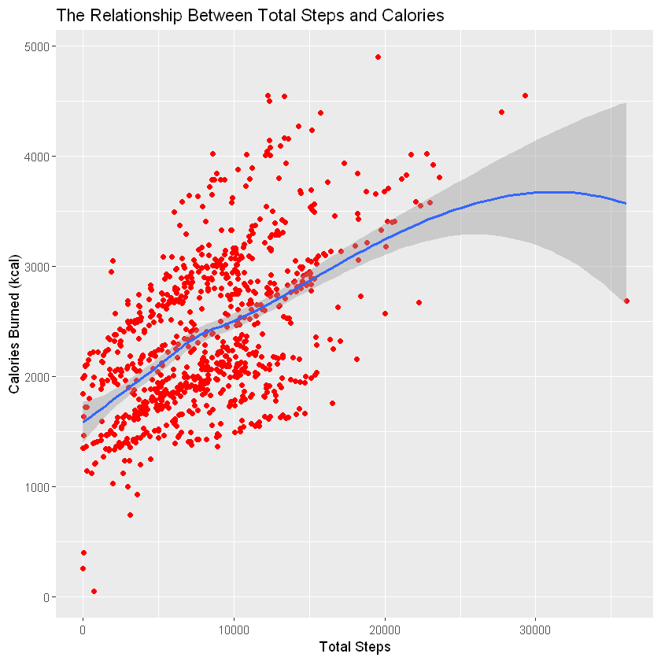

```r
ggplot(data=daily_activity) +
  geom_point(mapping=aes(x=TotalSteps, y=Calories), color="red") +
  geom_smooth(mapping=aes(x=TotalSteps, y=Calories)) +
  labs(title="The Relationship Between Total Steps and Calories", x="Total Steps", y="Calories Burned (kcal)")
```

*This graph shows a positive correlation between the total amount of steps and the calories burned - the larger the total amount of steps, the more calories burned.*

**Relationship between TotalSteps and Sedentary Minutes:**

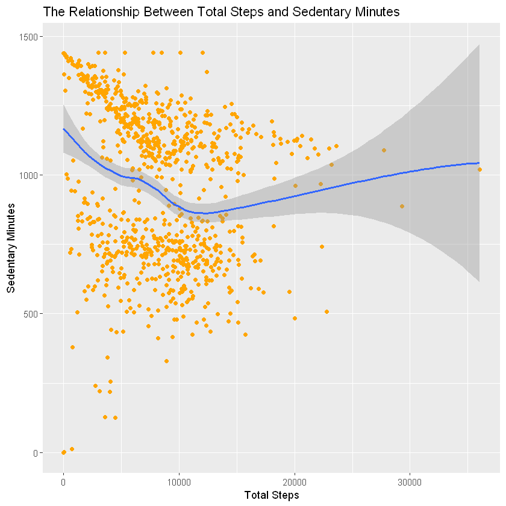

```r
ggplot(data=daily_activity) +
  geom_point(mapping=aes(x=TotalSteps, y=SedentaryMinutes), color="orange") +
  geom_smooth(mapping=aes(x=TotalSteps, y=SedentaryMinutes)) +
  labs(title="The Relationship Between Total Steps and Sedentary Minutes", x="Total Steps", y="Sedentary Minutes")
```

**Relationships between the Active Minutes (very, fairly, and lightly) and the number of Calories burned:**

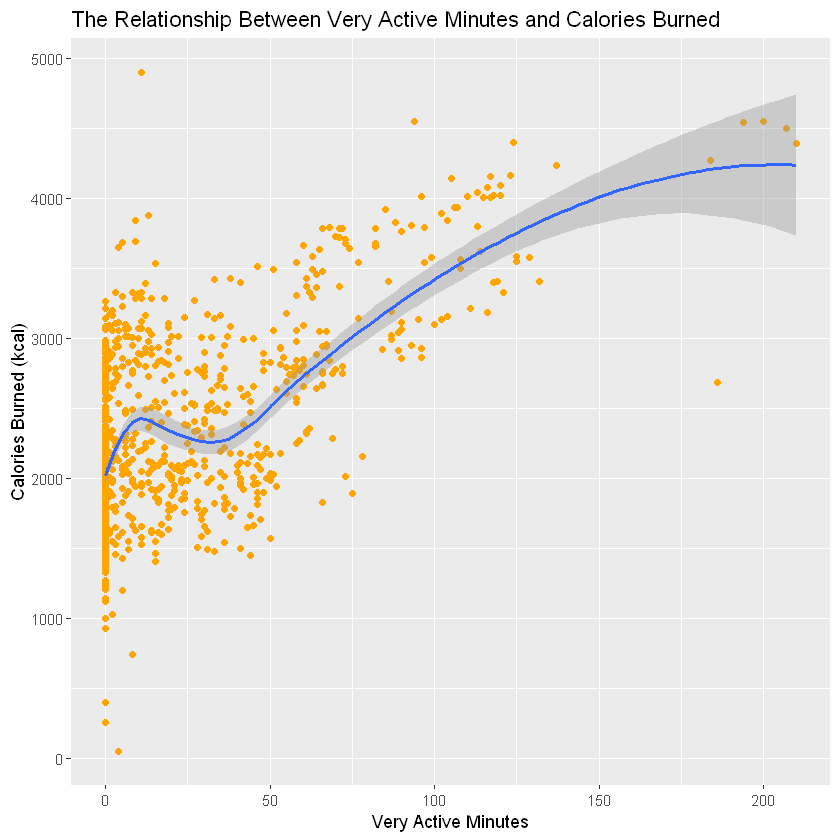

```r
ggplot(data=daily_activity) +
  geom_point(mapping=aes(x=VeryActiveMinutes, y=Calories), color="orange") +
  geom_smooth(mapping=aes(x=VeryActiveMinutes, y=Calories)) +
  labs(title="The Relationship Between Very Active Minutes and Calories Burned", x="Very Active Minutes", y="Calories Burned (kcal)")
```

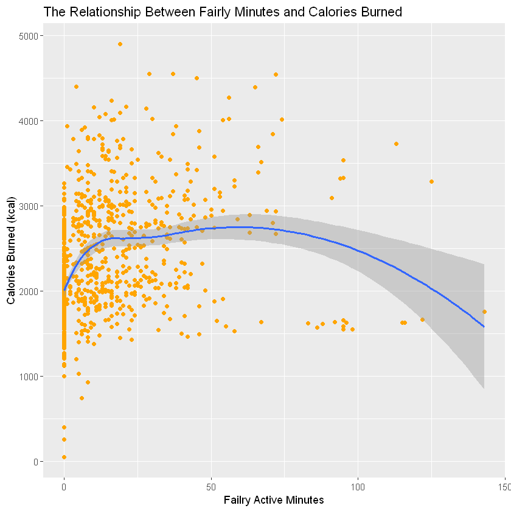

```r
ggplot(data=daily_activity) +
  geom_point(mapping=aes(x=FairlyActiveMinutes, y=Calories), color="orange") +
  geom_smooth(mapping=aes(x=FairlyActiveMinutes, y=Calories)) +
  labs(title="The Relationship Between Fairly Minutes and Calories Burned", x="Failry Active Minutes", y="Calories Burned (kcal)")
```

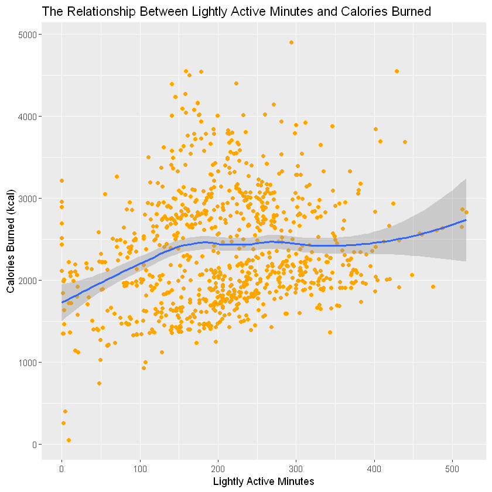

```r
ggplot(data=daily_activity) +
  geom_point(mapping=aes(x=LightlyActiveMinutes, y=Calories), color="orange") +
  geom_smooth(mapping=aes(x=LightlyActiveMinutes, y=Calories)) +
  labs(title="The Relationship Between Lightly Active Minutes and Calories Burned", x="Lightly Active Minutes", y="Calories Burned (kcal)")
```

**Relationship between the total minutes asleep and total minutes in bed:**

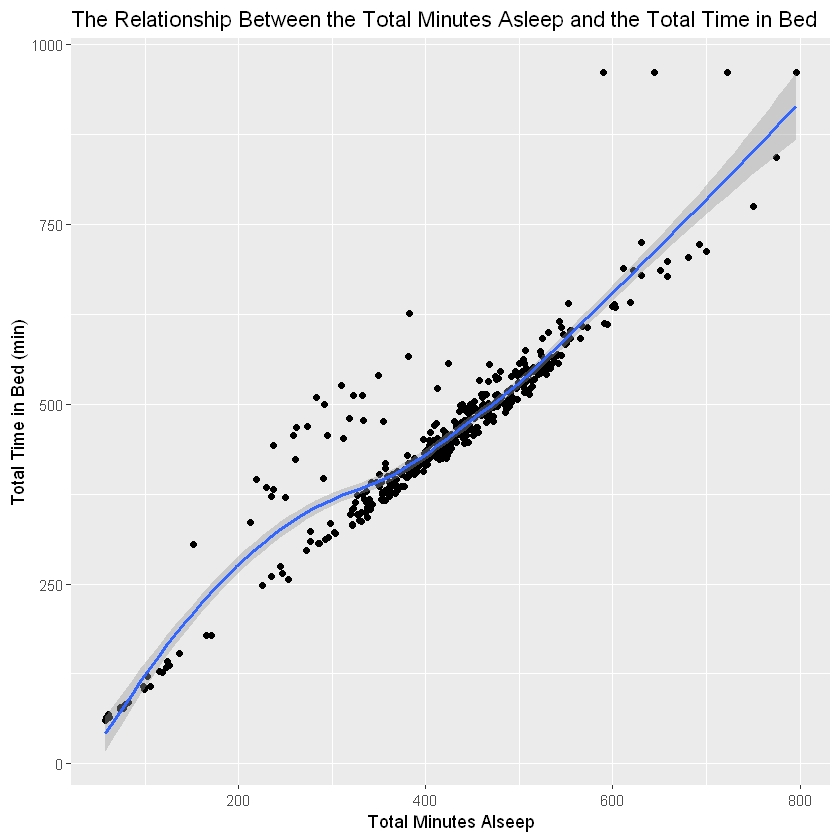

```r
ggplot(data=sleep_day_new, mapping=aes(x=TotalMinutesAsleep, y=TotalTimeInBed), color="purple") +
  geom_point() +
  geom_smooth() +
  labs(title="The Relationship Between the Total Minutes Asleep and the Total Time in Bed", x="Total Minutes Alseep", y="Total Time in Bed (min)")
```

*A positive correlation between the total minutes asleep and the amount of time spent in bed is seen. By using this data Bellabeat app can notify its customers about what will be the right time to go to bed so that they can get an adequate amount of sleep.*

## Phase 6: Act

**Recommendations for Bellabeat Marketing Strategy:**

- Based on the activity levels and amount of calories burned, users appear to burn more calories with more exercise. Therefore, Bellabeat should encourage users to exercise more through reminders. They could also offer app incentives, such as give users app credits for every 1000 steps, which can then be used to redeem prizes or vouchers.
- The data also shows many people lead either a lightly active or sedentary lifestyle, which may be due to the nature of their work or the lack of time to exercise. Bellabeat could have a section on their app for short workout videos or short exercises (for example, 10 minute videos) that their customers can follow along to if they don’t necessarily want to exercise alone.
- To encourage better sleeping habits, Bellabeat could incorporate reminders through an app that notifies users of the best time to go to sleep and wake up in order to feel refreshed in the morning and get adequate amount of sleep. The app could also automatically turn on ‘do not disturb’ mode and turn on ‘night mode’ on the customers’ phones to signal the user that they are not disturbed by messages or phone calls from family and friends.

**Recommendations for Bellabeat Marketing Strategy:**

- Based on the relationship of people's activity levels and calories burnt, people are more likely to burn more calories by doing more exercises. Here, Bellabeat app can encourage users to exercise more through reminders.
- To encourage the users Bellabeat can also offer app credits which can be used to redeem prizes or vouchers.
- Bellabeat can also offer short workout videos or short exercises for users who are lightly active due to their busy life schedule so that they can make time to do some exercises.
- Bellabeat can incorporate reminders that notifies users about the best time to go to sleep and wake up in order to feel refreshed in the morning and get adequate amount of sleep.